# Лабораторна робота № 3

## Тема: Аналіз складності алгоритмів. Алгоритми сортування

**Мета:** засвоїти аналіз складності алгоритмів як технологію на прикладі алгоритмів сортування методами включення та обміну.

Виконав студент груки КН-24-1 **Соломка Борис Олегович**

## Хід роботи

### 1. Теоретичний аналіз складності алгоритмів сортування

#### 1.1 Аналіз складності алгоритму сортування методом вставляння (insertion sort)

Алгоритм сортування методом вставляння працює за принципом послідовного додавання елементів до відсортованої частини масиву.

**Асимптотична складність:**

- Найкращий випадок: O(n) - коли масив уже відсортований
- Середній випадок: O(n²)
- Найгірший випадок: O(n²) - коли масив відсортований у зворотному порядку

Для масиву розміром n, алгоритм виконує приблизно n²/4 порівнянь та n²/4 обмінів у середньому випадку.

#### 1.2 Аналіз складності алгоритму сортування методом бульбашки (bubble sort)

Алгоритм сортування методом бульбашки працює шляхом багаторазового проходження через масив і обміну сусідніх елементів, якщо вони розташовані в неправильному порядку.

**Асимптотична складність:**

- Найкращий випадок: O(n) - з оптимізацією раннього завершення
- Середній випадок: O(n²)
- Найгірший випадок: O(n²)

Для масиву розміром n, алгоритм виконує n(n-1)/2 порівнянь у найгіршому випадку.

### 2. Імплементація алгоритмів сортування на Python

#### 2.1 Алгоритм сортування методом вставляння

```python
def insertion_sort(nums):
    for j in range(1, len(nums)):
        key = nums[j]
        i = j - 1
        while i >= 0 and nums[i] > key:
            nums[i + 1] = nums[i]
            i -= 1
        nums[i + 1] = key
    return nums
```

#### 2.2 Алгоритм сортування методом бульбашки

```python
def bubble_sort(nums):
    n = len(nums)
    for i in range(n):
        swapped = False
        for j in range(0, n-i-1):
            if nums[j] > nums[j+1]:
                nums[j], nums[j+1] = nums[j+1], nums[j]
                swapped = True
        if not swapped:
            break
    return nums
```

### 3. Дослідження часової складності алгоритмів на практиці

```python
import time
import random
import matplotlib.pyplot as plt
import numpy as np
%matplotlib inline
```

```python
def measure_time(sort_function, array):
    arr_copy = array.copy()
    start_time = time.time()
    sort_function(arr_copy)
    end_time = time.time()
    return end_time - start_time
```

```python
sizes = [5, 10, 50, 100, 500, 1000, 2000, 3000, 4000, 5000, 10000]
large_sizes = sizes + [20000, 50000]
insertion_times = {}
bubble_times = {}

for size in large_sizes:
    random_array = [random.randint(-1000, 1000) for _ in range(size)]
    insertion_times[size] = measure_time(insertion_sort, random_array)

    if size <= 10000:
        bubble_times[size] = measure_time(bubble_sort, random_array)

    print(f"Розмір масиву: {size}")
    print(f"Час сортування методом вставки: {insertion_times[size]:.6f} сек.")
    if size <= 10000:
        print(f"Час сортування методом бульбашки: {bubble_times[size]:.6f} сек.")
    print("---")
```

```
Розмір масиву: 5
Час сортування методом вставки: 0.000000 сек.
Час сортування методом бульбашки: 0.000000 сек.
---
Розмір масиву: 10
Час сортування методом вставки: 0.000000 сек.
Час сортування методом бульбашки: 0.000000 сек.
---
Розмір масиву: 50
Час сортування методом вставки: 0.000000 сек.
Час сортування методом бульбашки: 0.000000 сек.
---
Розмір масиву: 100
Час сортування методом вставки: 0.000997 сек.
Час сортування методом бульбашки: 0.000998 сек.
---
Розмір масиву: 500
Час сортування методом вставки: 0.011395 сек.
Час сортування методом бульбашки: 0.035917 сек.
---
Розмір масиву: 1000
Час сортування методом вставки: 0.060921 сек.
Час сортування методом бульбашки: 0.123152 сек.
---
Розмір масиву: 2000
Час сортування методом вставки: 0.169920 сек.
Час сортування методом бульбашки: 0.426740 сек.
---
Розмір масиву: 3000
Час сортування методом вставки: 0.371094 сек.
Час сортування методом бульбашки: 0.880442 сек.
---
Розмір масиву: 4000
Час сортування методом вставки: 0.600894 сек.
Час сортування методом бульбашки: 2.693828 сек.
---
Розмір масиву: 5000
Час сортування методом вставки: 3.148422 сек.
Час сортування методом бульбашки: 9.785205 сек.
---
Розмір масиву: 10000
Час сортування методом вставки: 12.795611 сек.
Час сортування методом бульбашки: 31.765978 сек.
---
Розмір масиву: 20000
Час сортування методом вставки: 44.561718 сек.
---
Розмір масиву: 50000
Час сортування методом вставки: 206.460912 сек.
---
```

### 4. Побудова графіків залежності часу виконання від розміру масиву

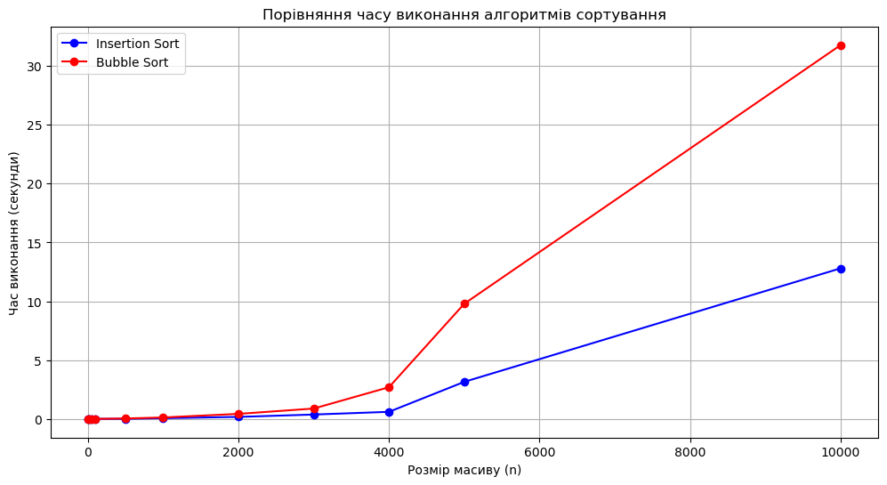

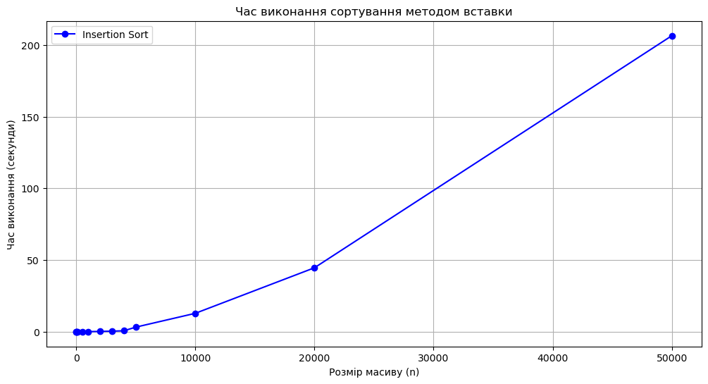

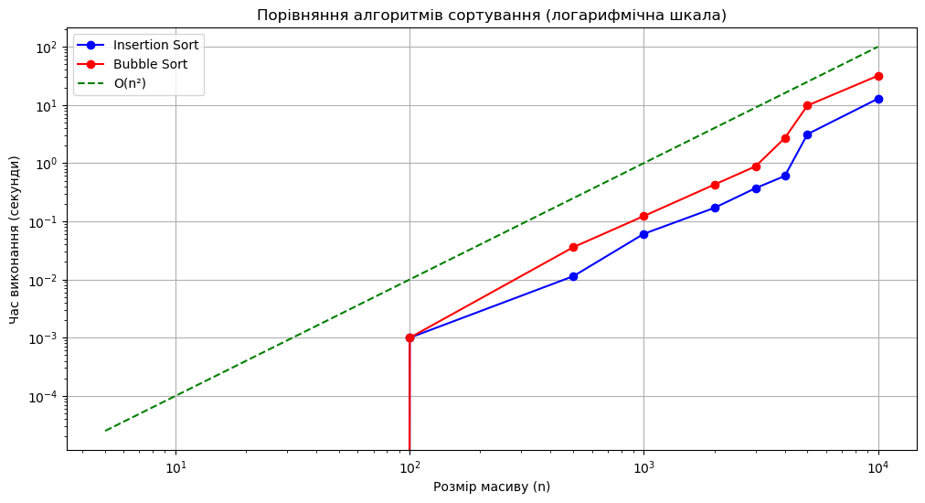

```python
# Магія побудови графіків за допомогою python та matplotlib
sizes_common = list(sizes)
insertion_times_common = [insertion_times[size] for size in sizes_common]
bubble_times_common = [bubble_times[size] for size in sizes_common]

plt.figure(figsize=(12, 6))
plt.plot(sizes_common, insertion_times_common, 'b-o', label='Insertion Sort')
plt.plot(sizes_common, bubble_times_common, 'r-o', label='Bubble Sort')
plt.xlabel('Розмір масиву (n)')
plt.ylabel('Час виконання (секунди)')
plt.title('Порівняння часу виконання алгоритмів сортування')
plt.legend()
plt.grid(True)
plt.show()

sizes_insertion = list(large_sizes)
insertion_times_all = [insertion_times[size] for size in sizes_insertion]

plt.figure(figsize=(12, 6))
plt.plot(sizes_insertion, insertion_times_all, 'b-o', label='Insertion Sort')
plt.xlabel('Розмір масиву (n)')
plt.ylabel('Час виконання (секунди)')
plt.title('Час виконання сортування методом вставки')
plt.legend()
plt.grid(True)
plt.show()

plt.figure(figsize=(12, 6))
plt.loglog(sizes_common, insertion_times_common, 'b-o', label='Insertion Sort')
plt.loglog(sizes_common, bubble_times_common, 'r-o', label='Bubble Sort')
plt.loglog(sizes_common, [n**2 * 1e-6 for n in sizes_common], 'g--', label='O(n²)')
plt.xlabel('Розмір масиву (n)')
plt.ylabel('Час виконання (секунди)')
plt.title('Порівняння алгоритмів сортування (логарифмічна шкала)')
plt.legend()
plt.grid(True)
plt.show()
```

## Висновки

Під час виконання лабораторної роботи було проведено теоретичний аналіз та дослідження часової складності двох алгоритмів сортування: методом вставляння (insertion sort) та методом бульбашки (bubble sort).

Теоретичний аналіз показав, що обидва алгоритми мають асимптотичну складність O(n²) у середньому та найгіршому випадках. Однак, алгоритм вставляння може досягати O(n) у найкращому випадку, коли масив уже відсортований.

Експериментальні дослідження підтвердили теоретичні розрахунки. Графіки залежності часу виконання від розміру масиву показали квадратичне зростання часу зі збільшенням розміру вхідних даних. Логарифмічний графік наочно демонструє відповідність часу виконання обох алгоритмів асимптотиці O(n²).

Під час виконання лабораторної роботи я навчився:

- Генерувати випадкові масиви за допомогою модуля random
- Вимірювати час виконання коду за допомогою модуля time
- Будувати інформативні графіки за допомогою бібліотеки matplotlib